# Assignment 4

Student Name: Andy Pham Student ID: 997942129

## Assignment 4: Rice SNPs and GWAS

This should be a knittable .Rmd file. Include this file, a .pdf and a .html when you turn in the assignment.

```r
data.geno <- read.csv("RiceSNPData/Rice_44K_genotypes.csv.gz", row.names=1, na.strings=c("NA","00"))
head(data.geno[,1:20])
```

```
##        X1_13147 X1_73192 X1_74969 X1_75852 X1_75953 X1_91016 X1_146625
## NSFTV1       TT       TT       CC       GG       TT       AA        CC
## NSFTV3       CC       CC       CC       AA       GG     <NA>        CC
## NSFTV4       CC       CC       CC       AA       GG       GG        CC
## NSFTV5       CC       CC       TT       GG       GG       AA        TT
## NSFTV6       CC       CC       CC       AA       GG       GG        CC
## NSFTV7       TT       TT       CC       GG       TT       AA        CC
##        X1_149005 X1_149754 X1_151492 X1_152899 X1_172755 X1_172923
## NSFTV1        TT        AA        AA        GG        CC        CC
## NSFTV3        GG        TT        GG        GG        CC        CC
## NSFTV4        GG        TT        GG        GG        CC        CC
## NSFTV5        GG        TT        AA      <NA>        CC        CC
## NSFTV6        GG        TT        GG        GG        CC        CC
## NSFTV7        TT        AA        AA        GG        CC        TT
##        X1_173692 X1_195327 X1_199011 X1_202999 X1_203126 X1_205867
## NSFTV1        AA        TT        TT        TT        AA        AA
## NSFTV3        TT        CC        TT        TT        CC        GG
## NSFTV4        TT        CC        TT        TT        CC        GG
## NSFTV5        AA        CC        TT        AA        CC        GG
## NSFTV6        TT        CC        TT        TT        CC        GG
## NSFTV7        AA        TT        TT        TT        AA        AA
##        X1_212693
## NSFTV1        GG
## NSFTV3        TT
## NSFTV4        TT
## NSFTV5        GG
## NSFTV6        TT
## NSFTV7        GG
```

```r
data.geno.2500 <- sample(data.geno, 2500)
dim(data.geno.2500)
```

```
## [1]  413 2500
```

```r
geno.numeric <- data.matrix(data.geno.2500)
head(geno.numeric[,1:20])
```

```
##        X3_4072652 X7_22304493 X11_21608153 X9_14197347 X4_3525344
## NSFTV1          1           1            1           2          2
## NSFTV3          1           3            2           2          1
## NSFTV4          1           3            1           2          2
## NSFTV5          1           1            1           2         NA
## NSFTV6          1           3            1           2          2
## NSFTV7          1           1            1           2          2
##        X4_5047855 X8_20666173 X11_7250873 X2_30754332 X11_4992377
## NSFTV1          1           1           2           2           1
## NSFTV3          2           2           1           1           1
## NSFTV4          1           1           1           1           3
## NSFTV5         NA           1           1           1           1
## NSFTV6         NA           1           1           1           3
## NSFTV7          1           1           1           2           1
##        X10_3091450 X6_4929359 X7_25522732 X2_7651810 X12_12566879
## NSFTV1           2          1           1          1            1
## NSFTV3           2          2           2          2            1
## NSFTV4           1          2           2          2            2
## NSFTV5           1          2           1          2            2
## NSFTV6           1          2           2          2            2
## NSFTV7           2          2           1         NA            1
##        X1_32969730 X2_20938098 X11_28446187 X7_15617681 X4_33342009
## NSFTV1           1           2            2           2           2
## NSFTV3           1           2            1           1           2
## NSFTV4           1           2            1           1           2
## NSFTV5           1           2            1           2           2
## NSFTV6           1           2            1           1           2
## NSFTV7           1           2            2           1           2
```

```r
genDist <- as.matrix(dist(geno.numeric))
geno.mds <- as.data.frame(cmdscale(genDist))
head(geno.mds)
```

```
##                V1         V2
## NSFTV1  17.225925  -1.547851
## NSFTV3 -24.133958   9.512564
## NSFTV4 -17.890744 -10.256934
## NSFTV5   3.476617  -5.831709
## NSFTV6 -16.663646  -9.993760
## NSFTV7   9.970922   2.660756
```

**EXERCISE 1:** Is there any evidence for populations structure (different sub populations)? If so, how many sub populations do you think the MDS plot reveals? What do you make of the individuals that are between the major groups? (Include your plot and code)

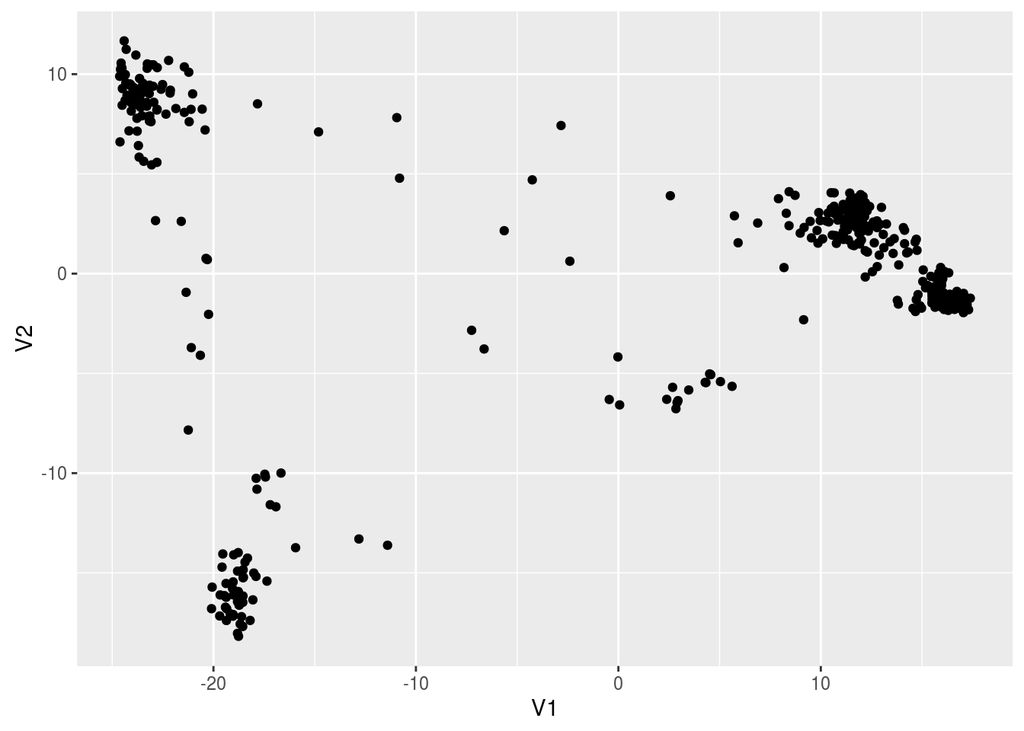

```r
p <- ggplot(geno.mds, aes(x=V1, y=V2))
p + geom_point()
```

**EXERCISE 2:**

- Use the `read.csv()` `head()` and `summary()` functions that you learned earlier to import and look at this file. Import the file into an object called “data.pheno”.
- Use merge() to merge the MDS scaled genotype data with the phenotype data. Here the column that we are merging on is the “row.name” column. So you can use `by="row.names"` or `by=1` in your call to merge. Use summary and head to look at the new object and make sure that it is as you expect.
- Include your code in the .Rmd

```r
data.pheno <- read.csv("RiceSNPData/RiceDiversity.44K.MSU6.Phenotypes.csv", row.names = 1, na.strings=c("NA","00"))
head(data.pheno)
```

```
##        Accession_Name Country_of_Origin  Region Alu.Tol
## NSFTV1       Agostano             Italy  Europe    0.73
## NSFTV3  Ai-Chiao-Hong             China  E Asia    0.30
## NSFTV4       NSF-TV 4           Unknown    <NA>    0.54
## NSFTV5       NSF-TV 5           Unknown    <NA>    0.44
## NSFTV6       ARC 7229             India  S Asia    0.57
## NSFTV7          Arias         Indonesia Pacific    0.86
##        Flowering.time.at.Arkansas Flowering.time.at.Faridpur
## NSFTV1                   75.08333                         64
## NSFTV3                   89.50000                         66
## NSFTV4                   94.50000                         67
## NSFTV5                   87.50000                         70
## NSFTV6                   89.08333                         73
## NSFTV7                  105.00000                         NA
##        Flowering.time.at.Aberdeen FT.ratio.of.Arkansas.Aberdeen
## NSFTV1                         81                     0.9269547
## NSFTV3                         83                     1.0783133
## NSFTV4                         93                     1.0161290
## NSFTV5                        108                     0.8101852
## NSFTV6                        101                     0.8820132
## NSFTV7                        158                     0.6645570
##        FT.ratio.of.Faridpur.Aberdeen Culm.habit Leaf.pubescence
## NSFTV1                     0.7901235        4.0               1
## NSFTV3                     0.7951807        7.5               0
## NSFTV4                     0.7204301        6.0               1
## NSFTV5                     0.6481481        3.5               1
## NSFTV6                     0.7227723        6.0               1
## NSFTV7                            NA        3.0               1
##        Flag.leaf.length Flag.leaf.width Awn.presence
## NSFTV1         28.37500       1.2833333            0
## NSFTV3         39.00833       1.0000000            0
## NSFTV4         27.68333       1.5166667            0
## NSFTV5         30.41667       0.8916667            0
## NSFTV6         36.90833       1.7500000            0
## NSFTV7         36.99000       1.5500000            1
##        Panicle.number.per.plant Plant.height Panicle.length
## NSFTV1                 3.068053     110.9167       20.48182
## NSFTV3                 4.051785     143.5000       26.83333
## NSFTV4                 3.124565     128.0833       23.53333
## NSFTV5                 3.697178     153.7500       28.96364
```

[output cut: 36 more lines]

```
## NSFTV7                   2.905                         2.506      light
##        Pericarp.color Straighthead.suseptability Blast.resistance
## NSFTV1          light                   4.833333                8
## NSFTV3          light                   7.831667                4
## NSFTV4          light                         NA                3
## NSFTV5          light                   8.333333                5
## NSFTV6          light                   8.166667                3
## NSFTV7          light                   8.585000                2
##        Amylose.content Alkali.spreading.value Protein.content
## NSFTV1        15.61333               6.083333            8.45
## NSFTV3        23.26000               5.638889            9.20
## NSFTV4        23.12000               5.527778            8.00
## NSFTV5        19.32333               6.027778            9.60
## NSFTV6        23.24000               5.444444            8.50
## NSFTV7        20.18667               6.000000           11.75
```

```r
summary(data.pheno)
```

```
##        Accession_Name     Country_of_Origin     Region      Alu.Tol
##  Azucena      :  2    United States: 41     America:83   Min.   :0.0300
##  Carolina Gold:  2    China        : 28     E Asia :73   1st Qu.:0.4000
##  Dom Sufid    :  2    India        : 27     S Asia :64   Median :0.6035
##  M-202        :  2    Bangladesh   : 24     Africa :39   Mean   :0.5874
##  Moroberekan  :  2    Japan        : 17     Europe :34   3rd Qu.:0.7500
##  (Other)      :373    (Other)      :246     (Other):78   Max.   :1.3500
##  NA's         : 30    NA's         : 30     NA's   :42   NA's   :43
##  Flowering.time.at.Arkansas Flowering.time.at.Faridpur
##  Min.   : 54.50             Min.   : 39.00
##  1st Qu.: 79.75             1st Qu.: 66.00
##  Median : 87.71             Median : 74.00
##  Mean   : 87.94             Mean   : 71.77
##  3rd Qu.: 96.83             3rd Qu.: 78.00
##  Max.   :150.50             Max.   :110.00
##  NA's   :39                 NA's   :108
##  Flowering.time.at.Aberdeen FT.ratio.of.Arkansas.Aberdeen
##  Min.   : 45.0              Min.   :0.3724
##  1st Qu.: 81.5              1st Qu.:0.7975
##  Median : 99.0              Median :0.8960
##  Mean   :107.1              Mean   :0.8949
##  3rd Qu.:114.0              3rd Qu.:1.0195
##  Max.   :306.0              Max.   :1.7031
##  NA's   :54                 NA's   :64
##  FT.ratio.of.Faridpur.Aberdeen   Culm.habit    Leaf.pubescence
##  Min.   :0.3459                Min.   :1.000   Min.   :0.0000
##  1st Qu.:0.6838                1st Qu.:3.000   1st Qu.:1.0000
##  Median :0.7720                Median :4.000   Median :1.0000
##  Mean   :0.7711                Mean   :4.228   Mean   :0.8507
##  3rd Qu.:0.8671                3rd Qu.:5.500   3rd Qu.:1.0000
##  Max.   :1.2885                Max.   :9.000   Max.   :1.0000
##  NA's   :109                   NA's   :29      NA's   :125
##  Flag.leaf.length Flag.leaf.width   Awn.presence
##  Min.   :15.42    Min.   :0.5917   Min.   :0.0000
##  1st Qu.:26.62    1st Qu.:1.0400   1st Qu.:0.0000
##  Median :30.05    Median :1.1833   Median :0.0000
##  Mean   :30.63    Mean   :1.2217   Mean   :0.2222
##  3rd Qu.:34.55    3rd Qu.:1.4111   3rd Qu.:0.0000
##  Max.   :49.44    Max.   :1.8917   Max.   :1.0000
##  NA's   :36       NA's   :36       NA's   :44
```

[output cut: 49 more lines]

```
##  Min.   :2.330              Min.   :0.000    Min.   : 0.00
##  1st Qu.:5.998              1st Qu.:2.000    1st Qu.:16.70
##  Median :7.165              Median :5.000    Median :21.13
##  Mean   :6.936              Mean   :5.039    Mean   :19.88
##  3rd Qu.:8.167              3rd Qu.:8.000    3rd Qu.:23.97
##  Max.   :9.000              Max.   :9.000    Max.   :27.96
##  NA's   :73                 NA's   :28       NA's   :12
##  Alkali.spreading.value Protein.content
##  Min.   :2.000          Min.   : 6.500
##  1st Qu.:5.403          1st Qu.: 7.950
##  Median :6.083          Median : 8.450
##  Mean   :5.974          Mean   : 8.593
##  3rd Qu.:6.938          3rd Qu.: 9.050
##  Max.   :7.000          Max.   :14.100
##  NA's   :10             NA's   :20
```

```r
data.all <- merge(geno.mds, data.pheno, by=0, all = T)
summary(data.all)
```

```
##   Row.names               V1               V2
##  Length:413         Min.   :-24.63   Min.   :-18.175
##  Class :AsIs        1st Qu.:-19.36   1st Qu.: -1.615
##  Mode  :character   Median : 10.72   Median :  1.487
##                     Mean   :  0.00   Mean   :  0.000
##                     3rd Qu.: 14.72   3rd Qu.:  3.549
##                     Max.   : 17.39   Max.   : 11.668
##
##        Accession_Name     Country_of_Origin     Region      Alu.Tol
##  Azucena      :  2    United States: 41     America:83   Min.   :0.0300
##  Carolina Gold:  2    China        : 28     E Asia :73   1st Qu.:0.4000
##  Dom Sufid    :  2    India        : 27     S Asia :64   Median :0.6035
##  M-202        :  2    Bangladesh   : 24     Africa :39   Mean   :0.5874
##  Moroberekan  :  2    Japan        : 17     Europe :34   3rd Qu.:0.7500
##  (Other)      :373    (Other)      :246     (Other):78   Max.   :1.3500
##  NA's         : 30    NA's         : 30     NA's   :42   NA's   :43
##  Flowering.time.at.Arkansas Flowering.time.at.Faridpur
##  Min.   : 54.50             Min.   : 39.00
##  1st Qu.: 79.75             1st Qu.: 66.00
##  Median : 87.71             Median : 74.00
##  Mean   : 87.94             Mean   : 71.77
##  3rd Qu.: 96.83             3rd Qu.: 78.00
##  Max.   :150.50             Max.   :110.00
##  NA's   :39                 NA's   :108
##  Flowering.time.at.Aberdeen FT.ratio.of.Arkansas.Aberdeen
##  Min.   : 45.0              Min.   :0.3724
##  1st Qu.: 81.5              1st Qu.:0.7975
##  Median : 99.0              Median :0.8960
##  Mean   :107.1              Mean   :0.8949
##  3rd Qu.:114.0              3rd Qu.:1.0195
##  Max.   :306.0              Max.   :1.7031
##  NA's   :54                 NA's   :64
##  FT.ratio.of.Faridpur.Aberdeen   Culm.habit    Leaf.pubescence
##  Min.   :0.3459                Min.   :1.000   Min.   :0.0000
##  1st Qu.:0.6838                1st Qu.:3.000   1st Qu.:1.0000
##  Median :0.7720                Median :4.000   Median :1.0000
##  Mean   :0.7711                Mean   :4.228   Mean   :0.8507
##  3rd Qu.:0.8671                3rd Qu.:5.500   3rd Qu.:1.0000
##  Max.   :1.2885                Max.   :9.000   Max.   :1.0000
##  NA's   :109                   NA's   :29      NA's   :125
```

[output cut: 57 more lines]

```
##  Min.   :2.330              Min.   :0.000    Min.   : 0.00
##  1st Qu.:5.998              1st Qu.:2.000    1st Qu.:16.70
##  Median :7.165              Median :5.000    Median :21.13
##  Mean   :6.936              Mean   :5.039    Mean   :19.88
##  3rd Qu.:8.167              3rd Qu.:8.000    3rd Qu.:23.97
##  Max.   :9.000              Max.   :9.000    Max.   :27.96
##  NA's   :73                 NA's   :28       NA's   :12
##  Alkali.spreading.value Protein.content
##  Min.   :2.000          Min.   : 6.500
##  1st Qu.:5.403          1st Qu.: 7.950
##  Median :6.083          Median : 8.450
##  Mean   :5.974          Mean   : 8.593
##  3rd Qu.:6.938          3rd Qu.: 9.050
##  Max.   :7.000          Max.   :14.100
##  NA's   :10             NA's   :20
```

```r
head(data.all[,1:20])
```

```
##   Row.names        V1         V2     Accession_Name Country_of_Origin
## 1    NSFTV1  17.22592 -1.5478507           Agostano             Italy
## 2   NSFTV10  16.87601 -1.5117489 Baghlani Nangarhar       Afghanistan
## 3  NSFTV100  14.75180  1.1715044           Lacrosse     United States
## 4  NSFTV101  10.51684  3.2606814             Lemont     United States
## 5  NSFTV102 -22.21452 10.6873269               <NA>              <NA>
## 6  NSFTV103  15.48335 -0.9254978         Luk Takhar       Afghanistan
##     Region Alu.Tol Flowering.time.at.Arkansas Flowering.time.at.Faridpur
## 1   Europe   0.730                   75.08333                         64
## 2 Mid East   0.902                   89.00000                         55
## 3  America   0.800                   84.11111                         78
## 4  America   0.630                   86.16667                         79
## 5     <NA>   0.440                         NA                         NA
## 6 Mid East   0.550                   84.00000                         78
##   Flowering.time.at.Aberdeen FT.ratio.of.Arkansas.Aberdeen
```

[output cut: 27 more lines]

**EXERCISE 3:** Prepare three different plots to explore if subgroups vary by 1) Amylose content; 2) Pericarp color; 3) Region. Do any of these seem to be associated with the different population groups? Briefly discuss.

*Hint 1* use `color=` argument to `qplot` or `ggplot` to color the point by the different traits  
*Hint 2* use `size=I(3)` as an argument to increase the point size (you can play with different values)  
*Hint 3* when plotting the Region data, the colors will be easier to interpret if you include the following at the end of the line with your qplot command: `+ scale_color_brewer(type="div")` This specifies that a diverging set of colors is used. (Try plotting with and without this).

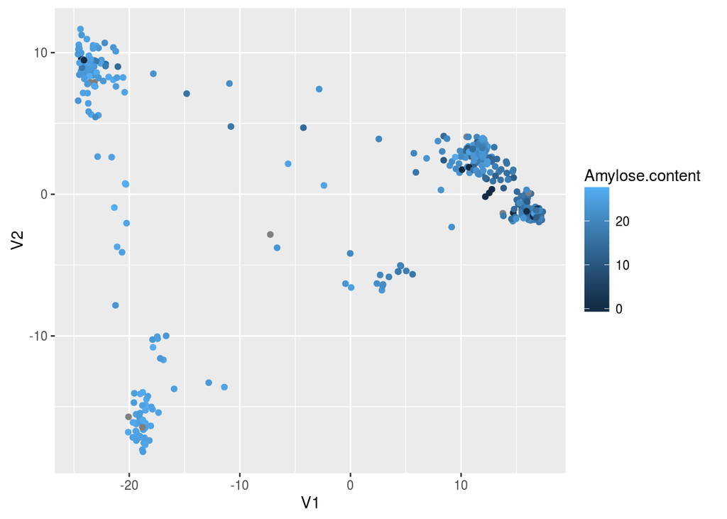

```r
amylose <- ggplot(data.all, aes(x=V1, y=V2, color=Amylose.content), size=I(3))
amylose + geom_point()
```

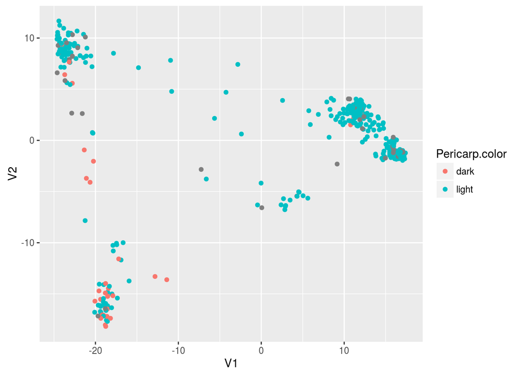

```r
pericarp <- ggplot(data.all, aes(x=V1, y=V2, color=Pericarp.color), size=I(3))
pericarp + geom_point()
```

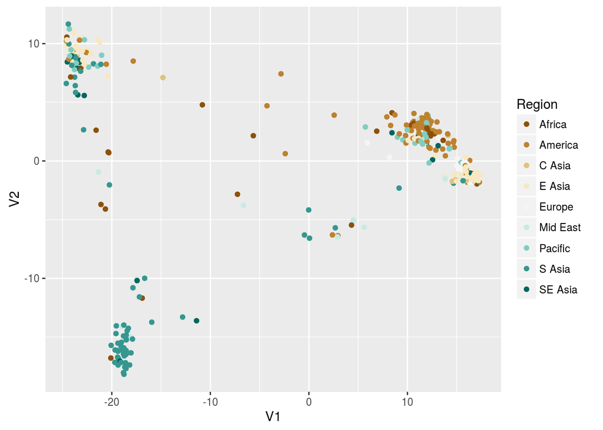

```r
region <- ggplot(data.all, aes(x=V1, y=V2, color=Region), size=I(3))
region + geom_point() + scale_color_brewer(type="div")
```

```r
data.geno.2500.c <- apply(data.geno.2500, 2, as.character)
data.geno.2500.ps <- matrix("", nrow=nrow(data.geno.2500.c)*2, ncol=ncol(data.geno.2500.c))
library(PSMix)
load("RiceSNPData/ps4.2500.RData")
#names(ps4)
#head(ps4$AmPr)
round(head(ps4$AmPr), 3)
```

```
##       [,1]  [,2]  [,3]  [,4]
## [1,] 0.000 1.000 0.000 0.000
## [2,] 0.000 0.000 1.000 0.000
## [3,] 0.000 0.000 0.126 0.874
## [4,] 0.385 0.263 0.037 0.315
## [5,] 0.017 0.000 0.134 0.850
## [6,] 0.926 0.026 0.048 0.000
```

```r
#head(ps4$AmId)
#table(ps4$AmId)
ps4.df <- as.data.frame(cbind(round(ps4$AmPr,3), ps4$AmId))
colnames(ps4.df) <- c(paste("pop",1:(ncol(ps4.df) - 1), sep=""), "popID")
head(ps4.df)
```

```
##    pop1  pop2  pop3  pop4 popID
## 1 0.000 1.000 0.000 0.000     2
## 2 0.000 0.000 1.000 0.000     3
## 3 0.000 0.000 0.126 0.874     4
## 4 0.385 0.263 0.037 0.315     1
## 5 0.017 0.000 0.134 0.850     4
## 6 0.926 0.026 0.048 0.000     1
```

```r
maxGenome <- apply(ps4$AmPr, 1, max)
ps4.df <- ps4.df[order(ps4.df$popID, -maxGenome),]
ps4.df$sampleID <- factor(1:413)
head(ps4.df)
```

```
##    pop1 pop2 pop3 pop4 popID sampleID
## 12    1    0    0    0     1        1
## 18    1    0    0    0     1        2
## 20    1    0    0    0     1        3
## 21    1    0    0    0     1        4
## 22    1    0    0    0     1        5
## 23    1    0    0    0     1        6
```

```r
ps4.df.melt <- melt(ps4.df, id.vars=c("popID", "sampleID"))
head(ps4.df.melt)
```

```
##   popID sampleID variable value
## 1     1        1     pop1     1
## 2     1        2     pop1     1
## 3     1        3     pop1     1
## 4     1        4     pop1     1
## 5     1        5     pop1     1
## 6     1        6     pop1     1
```

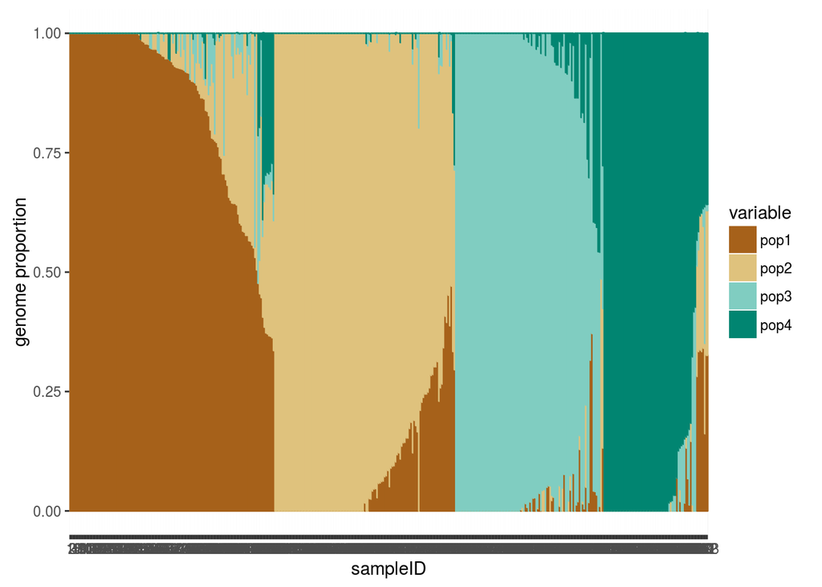

```r
p1 <- ggplot(aes(x=sampleID, y=value, color=variable, fill=variable), data=ps4.df.melt)
p1 <- p1 + geom_bar(stat = "identity")
p1 <- p1 + ylab("genome proportion") + scale_color_brewer(type="div") + scale_fill_brewer(type="div")
p1
```

**EXERCISE 4:** Re plot the MDS data, but include the population assignment in an informative way. How do the populations assignments relate to the MDS plot?

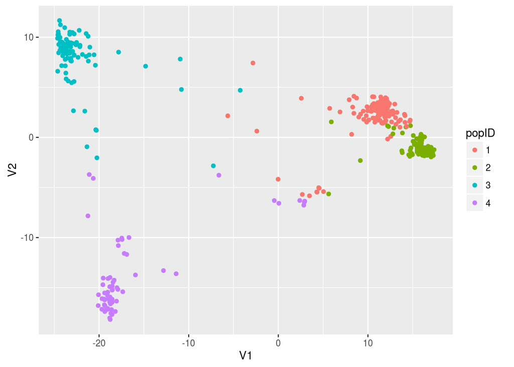

```r
geno.mds$popID <- factor(ps4$AmId)
colnames(ps4$AmPr) <- paste("pr", 1:4, sep="")
geno.mds <- cbind(geno.mds, ps4$AmPr)
p5 <- ggplot(geno.mds, aes(x=V1, y=V2, color=popID))
p5 + geom_point()
```

```r
save(data.pheno, geno.mds, file="data_from_SNP_lab.Rdata")
```

The population assignments coincide with the clusters on the MDS plot, with each population ID having its own cluster. This shows that the MDS plot clusters could be based around SNP similarity to populations whose individuals have genomes that have contributions from certain ancestral genomes.

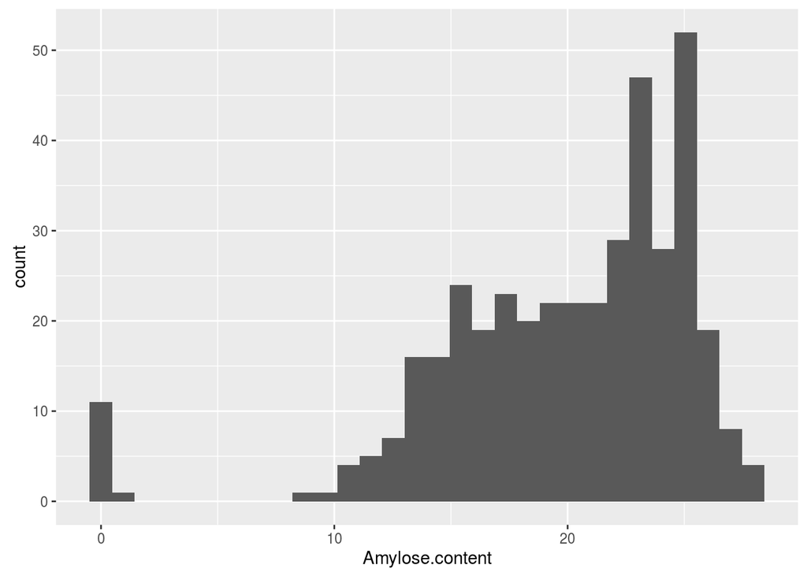

```r
data.pheno.mds <- merge(geno.mds, data.pheno, by="row.names")
qplot(x=Amylose.content, data=data.pheno.mds, geom="histogram")
```

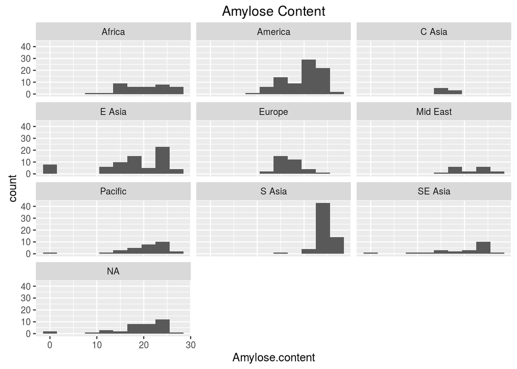

```r
pl <- ggplot(data=data.pheno.mds, aes(x=Amylose.content))
pl <- pl + geom_histogram(binwidth=3)
pl <- pl + facet_wrap(facets=~Region, ncol=3)
pl <- pl + ggtitle("Amylose Content")
pl
```

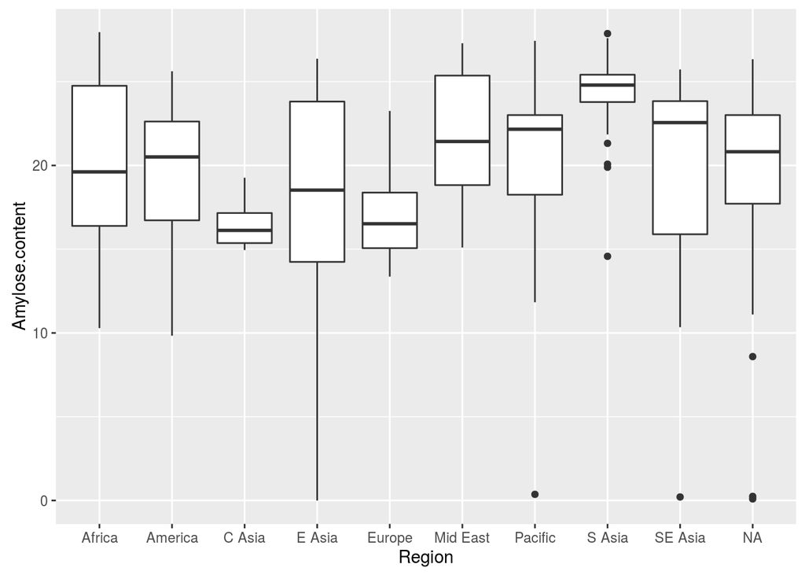

```r
qplot(x=Region, y=Amylose.content, geom="boxplot",data=data.pheno.mds)
```

**Exercise 5:**

- Plot your chosen trait data
- as a **single histogram** for all of the data
- as **separate histograms** for each of the 4 population assignments made by PSMix
- as a **boxplot** separated by population.
- Based on these histograms do you think that your trait varies by population?
- **BONUS** Try using the “violin” geom. What is this showing?

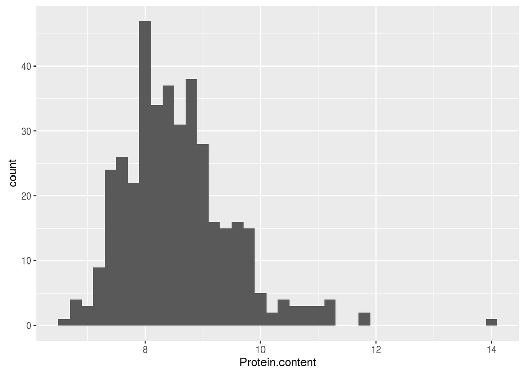

```r
protein_histo <- qplot(x=Protein.content, data=data.pheno.mds, geom="histogram", binwidth=0.2)
protein_4_histo <- ggplot(data.pheno.mds, aes(x=Protein.content))
protein_4_histo <- protein_4_histo + geom_histogram(binwidth=1) + facet_wrap(facets=~popID) + ggtitle("Protein Content")
protein_box <- ggplot(data.pheno.mds, aes(x=popID, y=Protein.content)) + geom_boxplot() + ggtitle("Protein Content")
protein_violin <- ggplot(data.pheno.mds, aes(x=popID, y=Protein.content)) + geom_violin() + ggtitle("Protein Content")
protein_histo
```

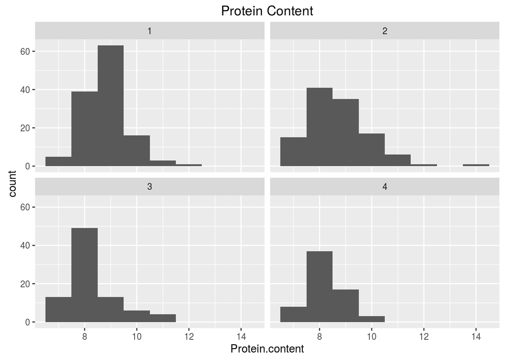

```r
protein_4_histo
```

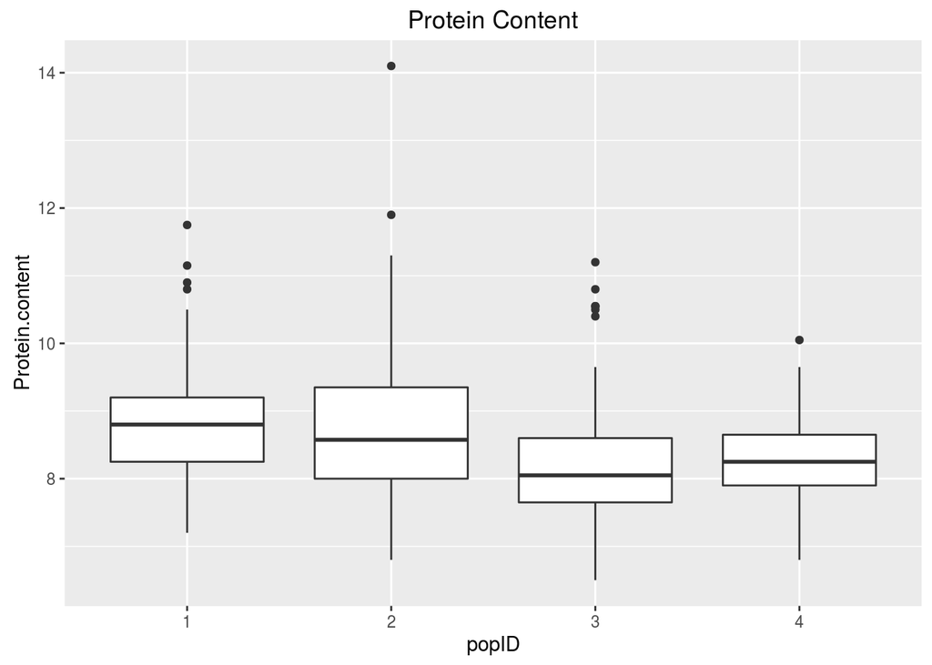

```r
protein_box
```

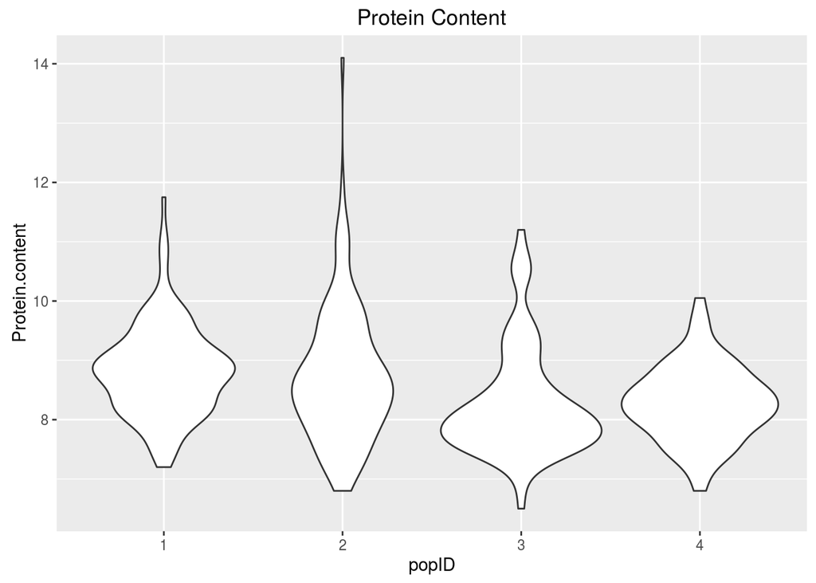

```r
protein_violin
```

Hint: you will need to use a different binwidth (or don’t specify it at all and let R choose the default). Hint: the relevant column names for population are “popID”.

**Exercise 6:**

- Obtain the mean of your trait for each of the 4 PSMix populations.
- Perform an ANOVA for your trait to test if it varies significantly by population. Show your code, the ANOVA output, and provide an interpretation.
- Discuss: Do your results present a problem for GWAS?

```r
tapply(X=data.pheno.mds$Protein.content, INDEX=data.pheno.mds$popID, FUN=mean, na.rm=T)
```

```
##        1        2        3        4
## 8.828346 8.738793 8.274412 8.286923
```

```r
aovl <- aov(Protein.content ~ popID, data=data.pheno.mds)
aovl1 <- aov(Protein.content ~ pr1, data=data.pheno.mds)
aovl2 <- aov(Protein.content ~ pr2, data=data.pheno.mds)
aovl3 <- aov(Protein.content ~ pr3, data=data.pheno.mds)
aovl4 <- aov(Protein.content ~ pr4, data=data.pheno.mds)
summary(aovl)
```

```
##              Df Sum Sq Mean Sq F value   Pr(>F)
## popID         3   24.2   8.072    9.74 3.28e-06 ***
## Residuals   389  322.4   0.829
## ---
## Signif. codes:  0 '***' 0.001 '**' 0.01 '*' 0.05 '.' 0.1 ' ' 1
## 20 observations deleted due to missingness
```

```r
summary(aovl1)
```

```
##              Df Sum Sq Mean Sq F value   Pr(>F)
## pr1           1   11.1  11.142   12.99 0.000354 ***
## Residuals   391  335.5   0.858
## ---
## Signif. codes:  0 '***' 0.001 '**' 0.01 '*' 0.05 '.' 0.1 ' ' 1
## 20 observations deleted due to missingness
```

```r
summary(aovl2)
```

```
##              Df Sum Sq Mean Sq F value Pr(>F)
## pr2           1    4.7   4.652   5.319 0.0216 *
## Residuals   391  342.0   0.875
## ---
## Signif. codes:  0 '***' 0.001 '**' 0.01 '*' 0.05 '.' 0.1 ' ' 1
## 20 observations deleted due to missingness
```

```r
summary(aovl3)
```

```
##              Df Sum Sq Mean Sq F value   Pr(>F)
## pr3           1   10.0   9.953   11.56 0.000744 ***
## Residuals   391  336.7   0.861
## ---
## Signif. codes:  0 '***' 0.001 '**' 0.01 '*' 0.05 '.' 0.1 ' ' 1
## 20 observations deleted due to missingness
```

```r
summary(aovl4)
```

```
##              Df Sum Sq Mean Sq F value  Pr(>F)
## pr4           1    8.4   8.388   9.696 0.00198 **
## Residuals   391  338.2   0.865
## ---
## Signif. codes:  0 '***' 0.001 '**' 0.01 '*' 0.05 '.' 0.1 ' ' 1
## 20 observations deleted due to missingness
```

The variation within population is significant since the p-values are all lower than 0.05. However, these p-values are higher than the p-value for the variation between populations. Thus, the variation between populations is greater than the variation within the populations themselves, and this suggests the traits do vary significantly between populations. These results could be a problem for GWAS.

**Exercise 7:** Describe and discuss the differences in the analysis with and without population structure correction. Which do you think is the better one to follow-up on, and why?

NOTE: I got this message: “Warning: the SNPs: Blast.resistance Amylose.content Alkali.spreading.value Protein.content are not included in the file with the genomic positions and they are discarded” when I was running setupSNP so I changed to Seed.volume as my chosen trait.

```r
snpinfo <- read.csv("RiceSNPData/snpInfo.csv",row.names=1)
head(snpinfo)
```

```
##        snp chr   pos
## 1 X1_13147   1 13147
## 2 X1_73192   1 73192
## 3 X1_74969   1 74969
## 4 X1_75852   1 75852
## 5 X1_75953   1 75953
## 6 X1_91016   1 91016
```

```r
head(data.pheno.mds)
```

```
##   Row.names        V1         V2 popID           pr1          pr2
## 1    NSFTV1  17.22592 -1.5478507     2  3.906153e-74 1.000000e+00
## 2   NSFTV10  16.87601 -1.5117489     2 5.975221e-105 1.000000e+00
## 3  NSFTV100  14.75180  1.1715044     2  4.524589e-01 5.475411e-01
## 4  NSFTV101  10.51684  3.2606814     1  9.279480e-01 3.621048e-02
## 5  NSFTV102 -22.21452 10.6873269     3  2.664270e-02 9.945103e-07
## 6  NSFTV103  15.48335 -0.9254978     2  5.139445e-02 9.121458e-01
##             pr3           pr4     Accession_Name Country_of_Origin
## 1 4.940656e-324 4.940656e-324           Agostano             Italy
## 2  0.000000e+00  0.000000e+00 Baghlani Nangarhar       Afghanistan
## 3 1.486226e-251 5.413008e-254           Lacrosse     United States
## 4  3.584154e-02  1.228608e-59             Lemont     United States
## 5  9.733563e-01  6.766981e-74               <NA>              <NA>
## 6  3.645977e-02 4.916478e-141         Luk Takhar       Afghanistan
##     Region Alu.Tol Flowering.time.at.Arkansas Flowering.time.at.Faridpur
```

[output cut: 76 more lines]

```r
rownames(data.pheno.mds) <- data.pheno.mds$Row.names
data.geno.pheno <- merge(data.pheno.mds, data.geno, by="row.names")
library(SNPassoc)
data.geno.pheno3 <- data.geno.pheno[, c(1:51, grep("X3_", colnames(data.geno.pheno)))]
snpinfo3 <- snpinfo[snpinfo$chr==3,]
snps3 <- setupSNP(data.geno.pheno3,48:ncol(data.geno.pheno3),sort=T,info=snpinfo3,sep="")
```

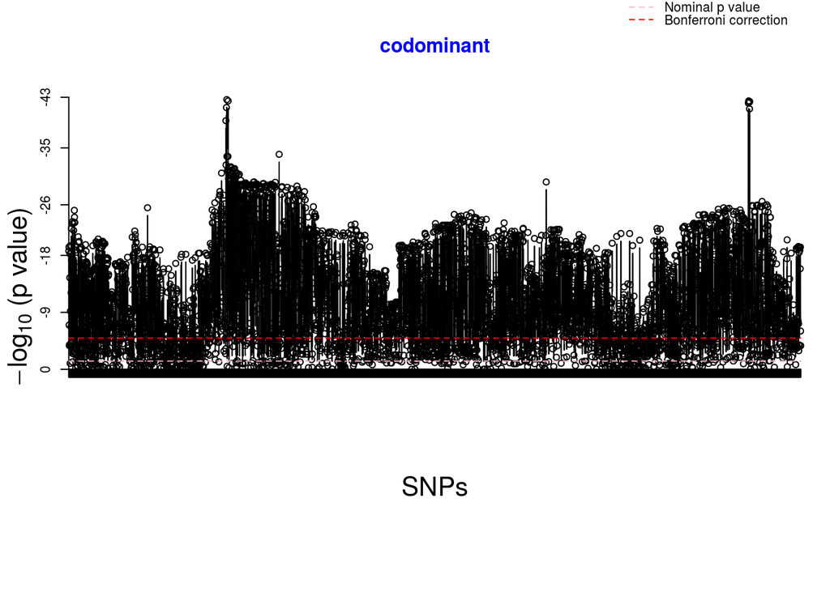

```r
wg3 <- WGassociation(Seed.volume,data=snps3,model="co",genotypingRate=50)
plot(wg3,print.label.SNPs=FALSE)
```

```r
sum(codominant(wg3) < 1e-5)
```

```
## [1] 3042
```

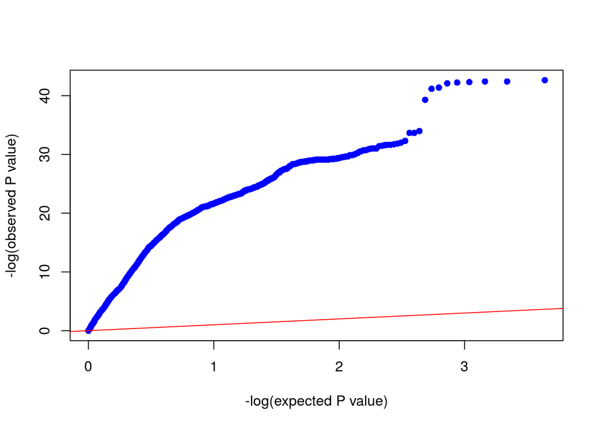

```r
qqpval(codominant(wg3))
```

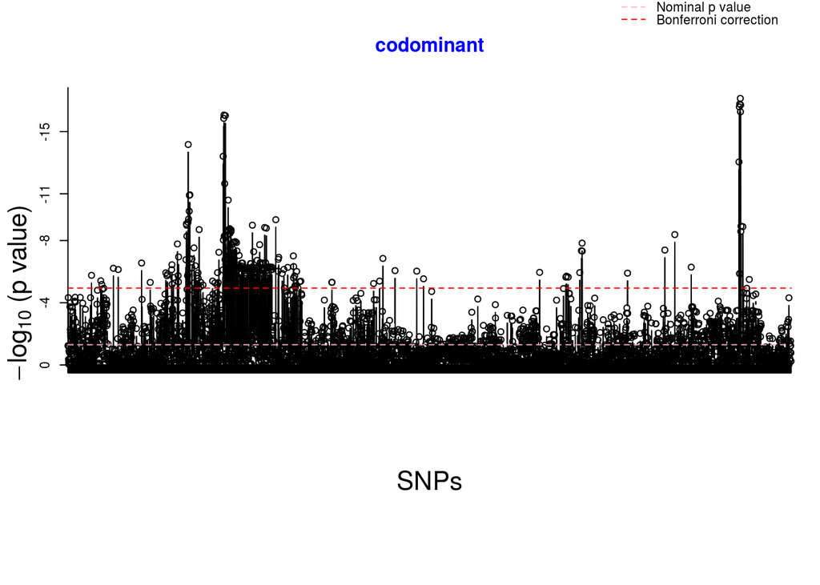

```r
wg3.corrected <- WGassociation(Seed.volume ~ pr1 + pr2 + pr3 + pr4,data=snps3,model="co",genotypingRate=50)
plot(wg3.corrected, print.label.SNPs = FALSE)
```

```r
sum(codominant(wg3.corrected) < 1e-5)
```

```
## [1] 222
```

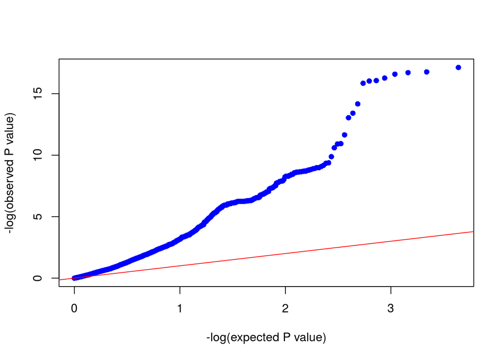

```r
qqpval(codominant(wg3.corrected))
```

In the analysis without the population structure, there were overwhelmingly numerous peaks in the plot, and the observed values in the graph was far off from the expected values. The plot and graph were so saturated that it was impossible to find anything conclusive about the SNP data since the hits were being reported everywhere. It becomes hard to discern the SNPs that caused genetic differences between populations and SNPs that hit by pure chance. With the corrected population structure, the plot was less cluttered, it was easier to identify the GWAS peaks. The observed values were also closer to the expected values line in the graph. The population structure correction, which accounted for the subpopulations within the populations, is more accurate and would be the better one to follow up on because it takes out the population stratification which our data has.

**Exercise 8:** Look for genes close to your SNP at the [rice genome browser](http://rice.plantbiology.msu.edu/cgi-bin/gbrowse/rice/). Pick a significant SNP from your analysis and enter its chromosome and position in the search box. The browser wants you to enter a start and stop position, so for example, you should enter “Chr3:30449857..30449857” and then choose “show 20kb” from the pulldown menu on the left hand side. Report the SNP you chose and the three closest genes. These are candidate genes for determining the phenotype of your trait of interest in the rice population. Briefly discuss these genes as possible candidates for the GWAS peak. (Include a screenshot of the genome browser)

**SNP**: X3_3557852

**Genes closest**: *LOC_Os03g06970.1*: this gene is a tetratricopeptide repeat domain containing protein and would not be a good candidate for GWAS since it is a repeating element and probably non-coding. *LOC_Os03g06980.1*: this gene is a nucleic acid binding protein and would be a good candidate for GWAS, since changes in this protein would result in changes in the gene due to its nucleic acid binding affinity. *LOC_Os03g06960.1*: this gene is a membrane protein associated with transport, and thus would a good candidate for GWAS, since it would affect cell function and phenotype should mutations arise.

```r
snpinfo3[codominant(wg3.corrected) < 1e-5,]
```

```
##               snp chr      pos
## 10480  X3_1145687   3  1145687
## 10536  X3_1656578   3  1656578
## 10542  X3_1672146   3  1672146
## 10612  X3_2149854   3  2149854
## 10641  X3_2400018   3  2400018
## 10782  X3_3557852   3  3557852
## 10834  X3_3986247   3  3986247
## 10928  X3_4701087   3  4701087
## 10935  X3_4757196   3  4757196
## 10938  X3_4763350   3  4763350
## 10963  X3_4876643   3  4876643
## 10965  X3_4885781   3  4885781
## 10966  X3_4893619   3  4893619
## 10974  X3_4984022   3  4984022
```

[output cut: 208 more lines]

```r
cbind(snpinfo3[codominant(wg3.corrected) < 1e-5,], codominant(wg3.corrected)[codominant(wg3.corrected) < 1e-5])
```

```
##               snp chr      pos
## 10480  X3_1145687   3  1145687
## 10536  X3_1656578   3  1656578
## 10542  X3_1672146   3  1672146
## 10612  X3_2149854   3  2149854
## 10641  X3_2400018   3  2400018
## 10782  X3_3557852   3  3557852
## 10834  X3_3986247   3  3986247
## 10928  X3_4701087   3  4701087
## 10935  X3_4757196   3  4757196
## 10938  X3_4763350   3  4763350
## 10963  X3_4876643   3  4876643
## 10965  X3_4885781   3  4885781
## 10966  X3_4893619   3  4893619
## 10974  X3_4984022   3  4984022
```

[output cut: 431 more lines]